# Como criar gráficos usando o ggplot | Tutorial Completo ggplot2

luisotavio.pro

19/03/2021

(esse material complementar foi 100% produzido usando a linguagem R)

Esse é um material complementar, ou seja, não substitui você assistir a live completa.

[**Clique aqui para assistir a live**](https://youtu.be/e8seIwgj77c)

Objetivo: te ensinar todos os conceitos para fazer qualquer gráfico usando a biblioteca ggplot2

**ggplot2** é uma biblioteca da linguagem R que te permite construir vários e vários tipos de gráficos diferentes.

MAIOR VANTAGEM NA MINHA OPINIÃO => os gráficos possuem uma capacidade de customização absurda!

Isso só é possível porque os gráficos são compostos por vários elementos independentes.

### Os 3 elementos de QUALQUER gráfico ggplot

1 - OS DADOS

2 - ESTÉTICA -> quais serão as variáveis de cada eixo

3 - OBJETO GEOMÉTRICO - Como as observações serão representadas no gráfico. Geralmente se utiliza a função geom*** para criar essa camada.

### PARTE PRÁTICA

Primeiro passo: instalar a biblioteca `ggplot2`, caso você não tenha feito antes

```r
install.packages("ggplot2")
```

#### carregar a biblioteca

```r
library(ggplot2)
```

Cabeçalho dos dados

```r
library(knitr)
kable(head(mtcars))
```

|  | mpg | cyl | disp | hp | drat | wt | qsec | vs | am | gear | carb |
| --- | --- | --- | --- | --- | --- | --- | --- | --- | --- | --- | --- |
| Mazda RX4 | 21.0 | 6 | 160 | 110 | 3.90 | 2.620 | 16.46 | 0 | 1 | 4 | 4 |
| Mazda RX4 Wag | 21.0 | 6 | 160 | 110 | 3.90 | 2.875 | 17.02 | 0 | 1 | 4 | 4 |
| Datsun 710 | 22.8 | 4 | 108 | 93 | 3.85 | 2.320 | 18.61 | 1 | 1 | 4 | 1 |
| Hornet 4 Drive | 21.4 | 6 | 258 | 110 | 3.08 | 3.215 | 19.44 | 1 | 0 | 3 | 1 |
| Hornet Sportabout | 18.7 | 8 | 360 | 175 | 3.15 | 3.440 | 17.02 | 0 | 0 | 3 | 2 |
| Valiant | 18.1 | 6 | 225 | 105 | 2.76 | 3.460 | 20.22 | 1 | 0 | 3 | 1 |

#### NOSSO PRIMEIRO GRÁFICO

Lembre-se: **o gráfico ggplot é composto por 3 elementos**

1 - Dados = mtcars

2 - Estética (definição dos eixos) = aes(x = wt, y = hp)

3 - Marcas geográficas = geom_point()

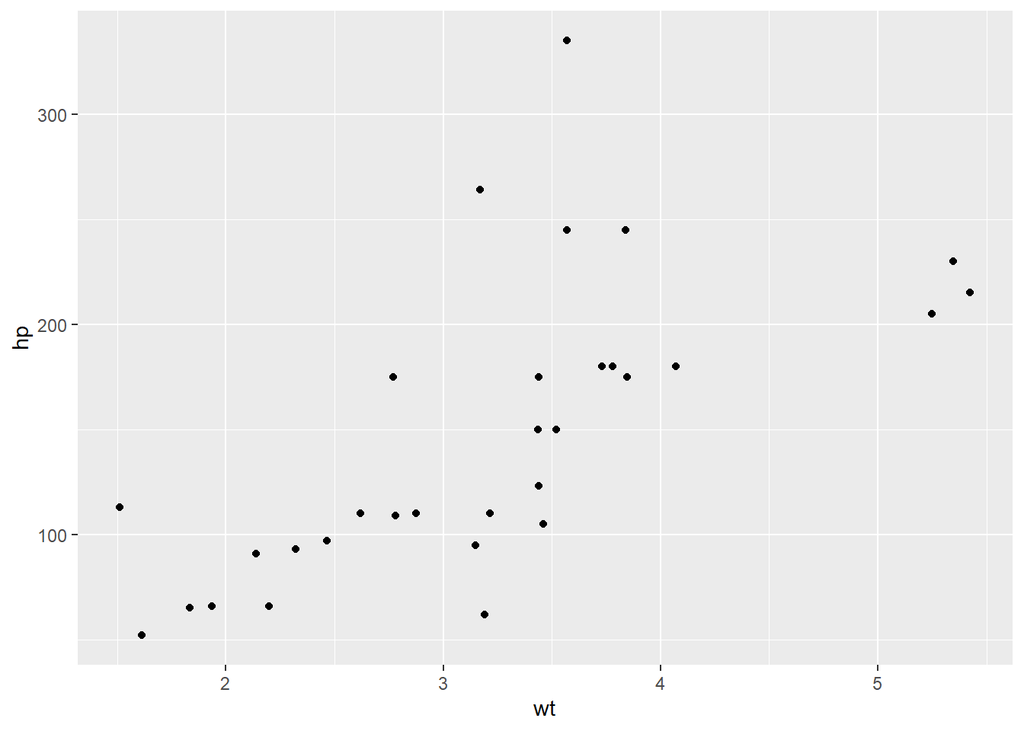

```r
ggplot(mtcars, aes(x = wt, y = hp)) +
  geom_point()
```

#### Fazendo Histogramas (gráfico de frequência) para variáveis contínuas e categóricas

```r
kable(head(iris))
```

| Sepal.Length | Sepal.Width | Petal.Length | Petal.Width | Species |
| --- | --- | --- | --- | --- |
| 5.1 | 3.5 | 1.4 | 0.2 | setosa |
| 4.9 | 3.0 | 1.4 | 0.2 | setosa |
| 4.7 | 3.2 | 1.3 | 0.2 | setosa |
| 4.6 | 3.1 | 1.5 | 0.2 | setosa |
| 5.0 | 3.6 | 1.4 | 0.2 | setosa |
| 5.4 | 3.9 | 1.7 | 0.4 | setosa |

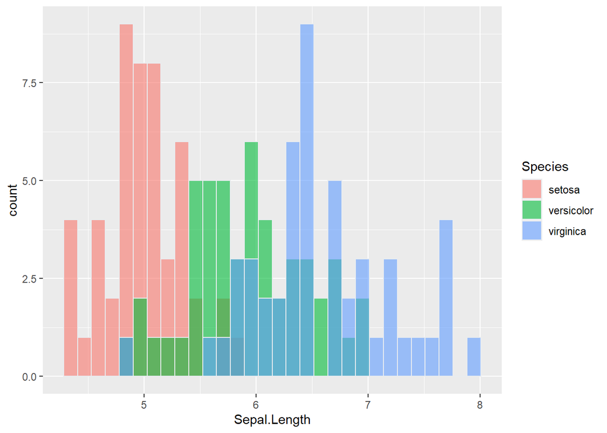

```r
ggplot(iris, aes(x=Sepal.Length, fill=Species)) +
  geom_histogram( color="#e9ecef", alpha=0.6, position = 'identity')
```

O parâmetro *alpha* define a transparência da cor.

#### Construindo um gráfico tradicional de colunas ou barras:

```r
### alterando o tema dos nossos gráficos
library(dplyr)
theme_set(theme_bw())
```

```r
## calcular o peso médio dos carros por cilindros
meus_dados<-mtcars %>%
  group_by(cyl) %>%
  summarise(peso = mean(wt)) %>%
  ungroup()
```

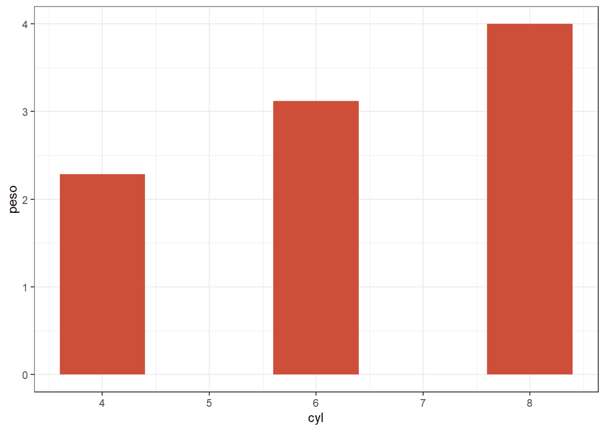

```r
### como fazer um gráfico de coluna
ggplot(meus_dados, aes(x=cyl, y=peso)) +
  geom_bar(stat="identity", width=0.8, fill="tomato3")
```

O parâmetro width define a largura das colunas. O parâmetro fill define a cor que irá preencher as colunas.

O comando acima (função geom_bar com stat=“identity”) é equivalente a função geom_col.

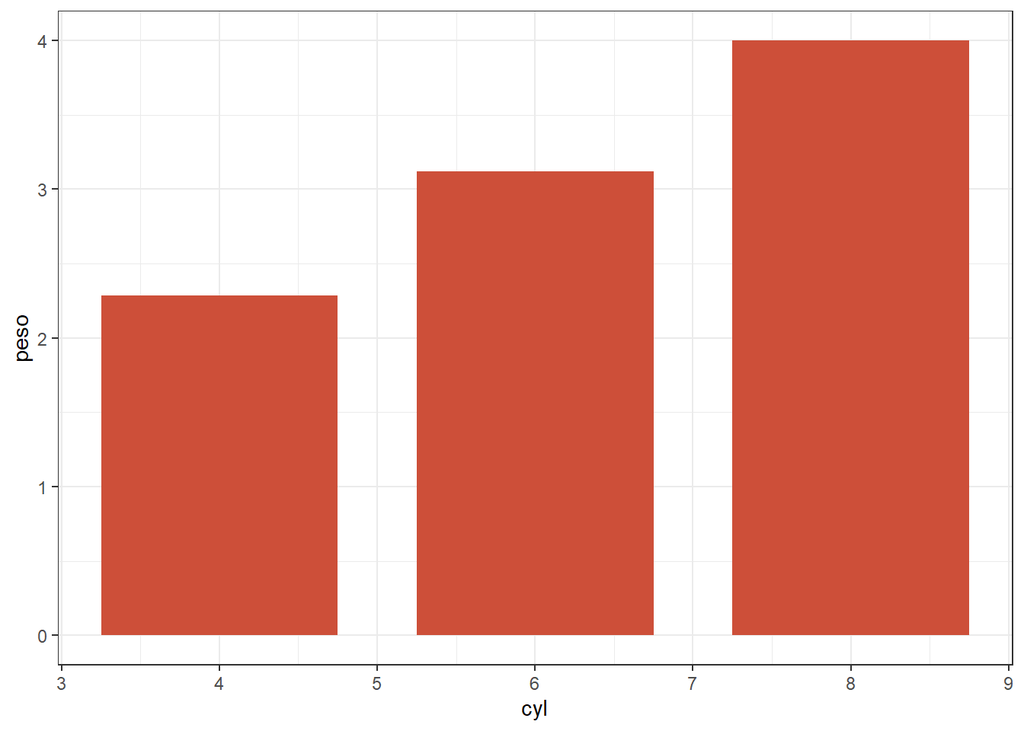

```r
ggplot(meus_dados, aes(x=cyl, y=peso)) +
  geom_col(width=1.5, fill="tomato3")
```

#### Como fazer para definir as escalas dos eixos?

Delimitando as amplitudes do eixo x e do eixo y.

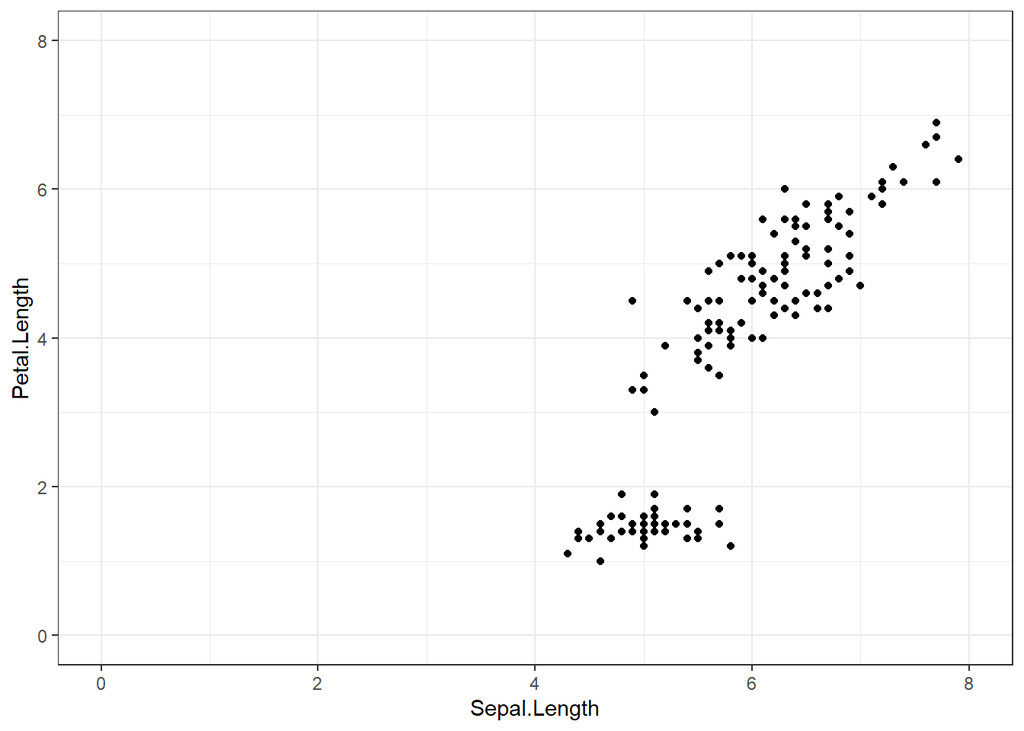

```r
ggplot(iris, aes(x=Sepal.Length, y=Petal.Length)) +
  geom_point() +
  # garantir que o gráfico tem o ponto (0,0)
  expand_limits(x = 0, y = 0) +
  # escolhendo as amplitudes dos eixos
  xlim(0,8) + ylim(0,8)
```

#### Como adicionar a reta de regressão e o r^2

```r
# install.packages("ggpmisc")
library(ggpmisc)
# Transformar a variável cilindros em categórica
mtcars$cyl <- as.factor(mtcars$cyl)
```

### Criando nosso gráfico

```r
g<-ggplot(data = mtcars, aes(x = wt, y = hp)) +
  #suavização
  geom_smooth(method = "lm", se=FALSE, formula = y ~ x) +
  # escrever a formula do modelo + r2
  stat_poly_eq(formula = y ~ x,
               aes(label = paste(..eq.label.., ..rr.label.., sep = "~~~")),
               parse = TRUE) +
  #adicionar os pontos e colorir de acordo com o número de cilindros
  geom_point(aes(colour = cyl))
```

#### adicione o texto que você quiser

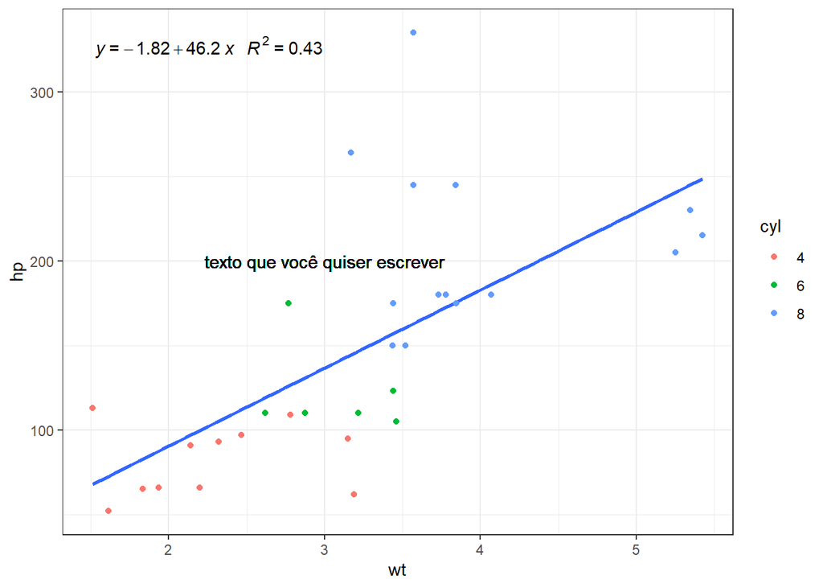

```r
g + geom_text(x = 3, y = 200, label = "texto que você quiser escrever")
```

#### VOCÊ PODE ESCOLHER UM TEMA PARA O SEU GRÁFICO

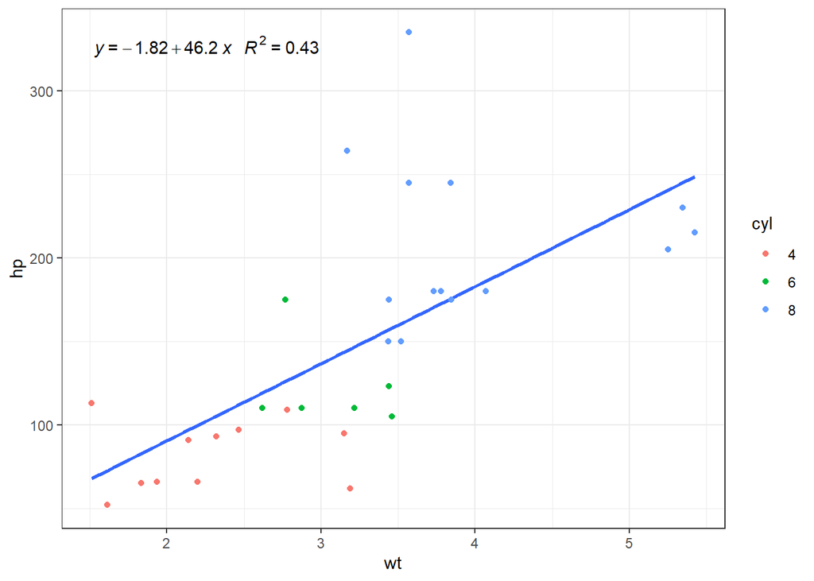

```r
g + theme_bw()
```

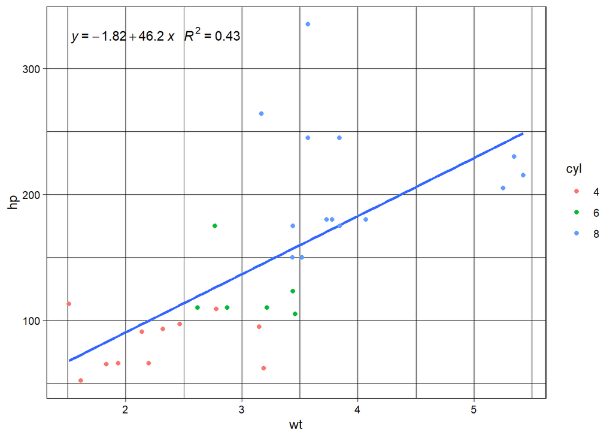

```r
g + theme_linedraw()
```

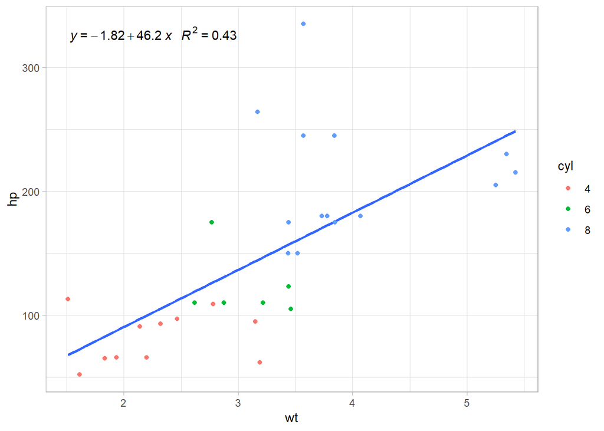

```r
g + theme_light()
```

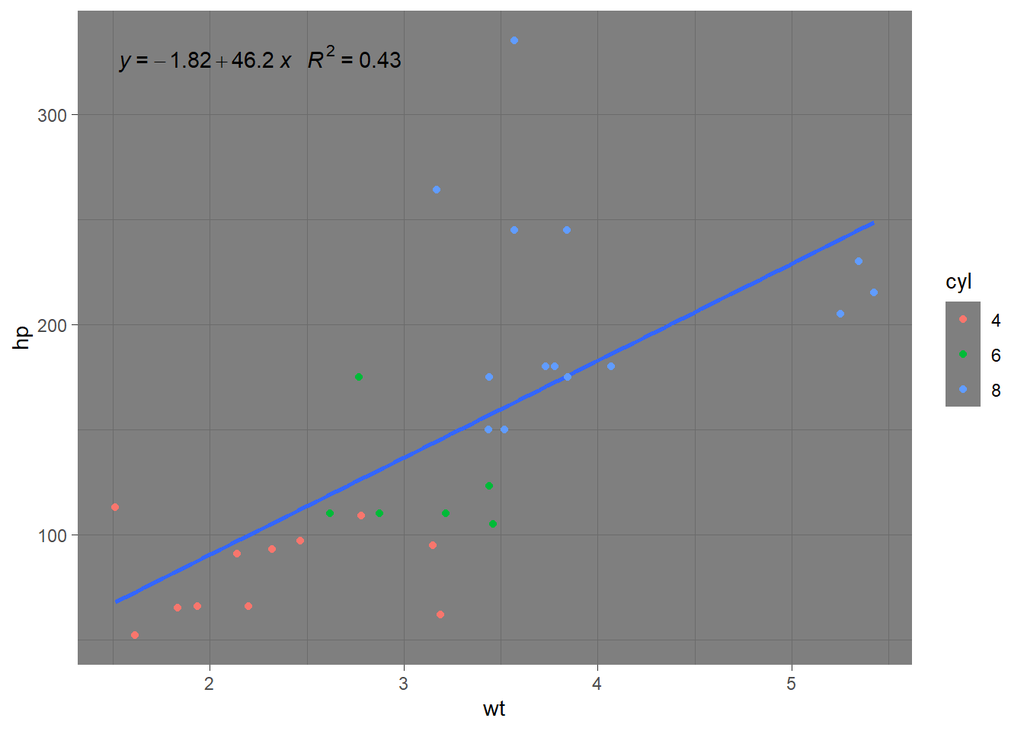

```r
g + theme_dark()
```

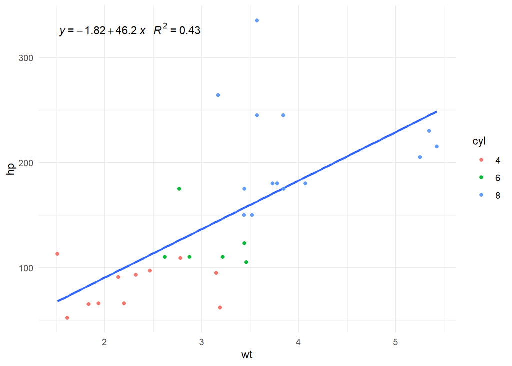

```r
g + theme_minimal()
```

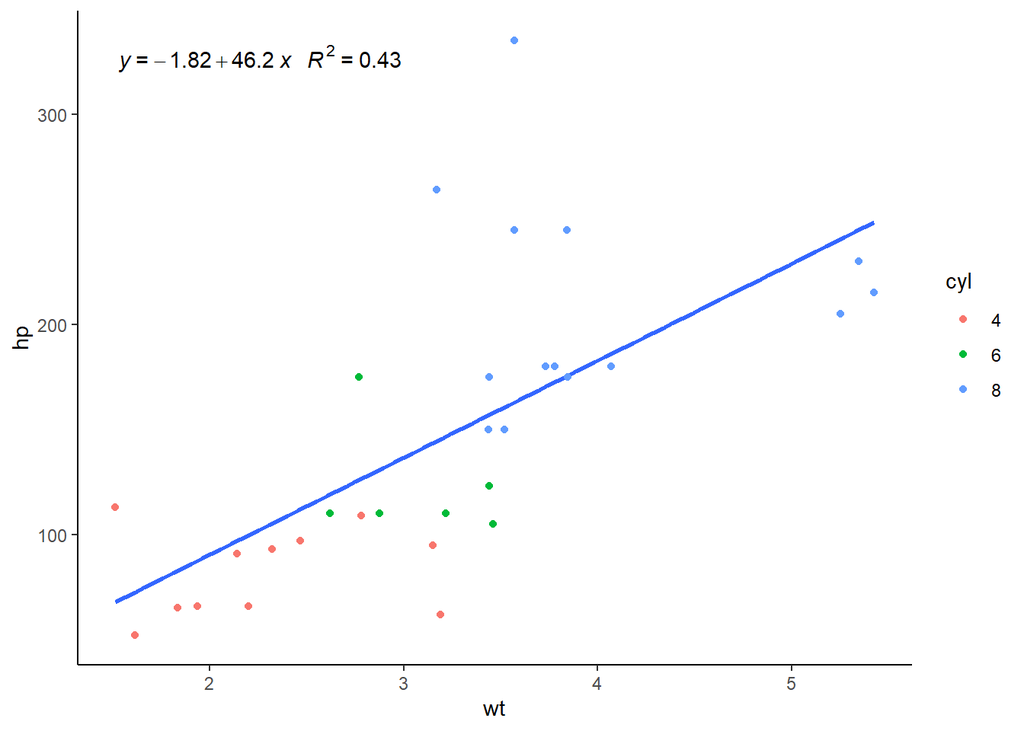

```r
g + theme_classic()
```

#### Criar as coordenadas do gráfico de acordo com uma variável ou duas variáveis

Criando gráficos para cada categoria da variável `am`

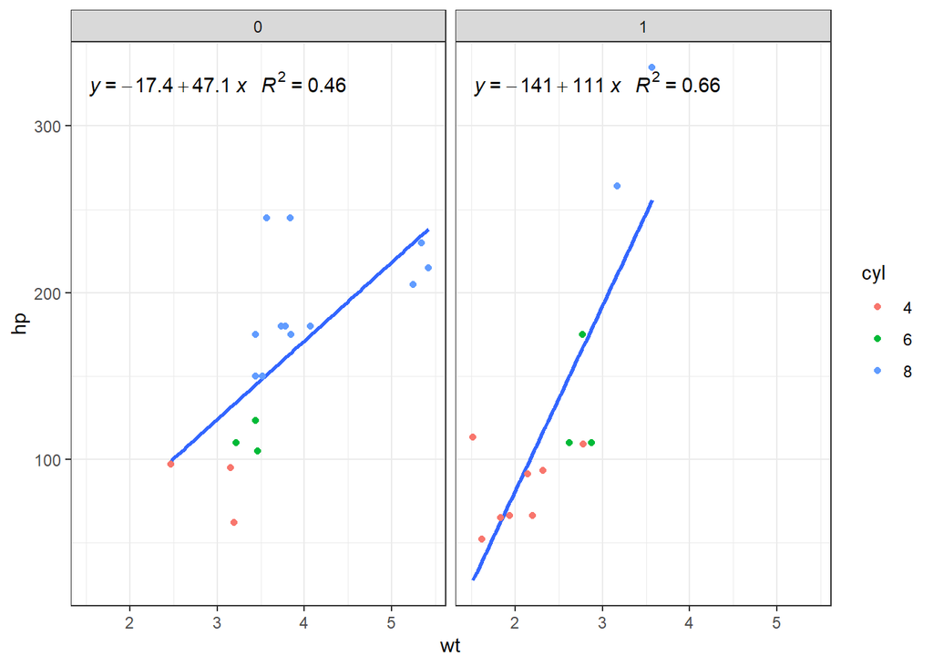

```r
g + facet_grid( ~ am)
```

Criando gráficos para cada combinação das variáveis `am` e `gear`

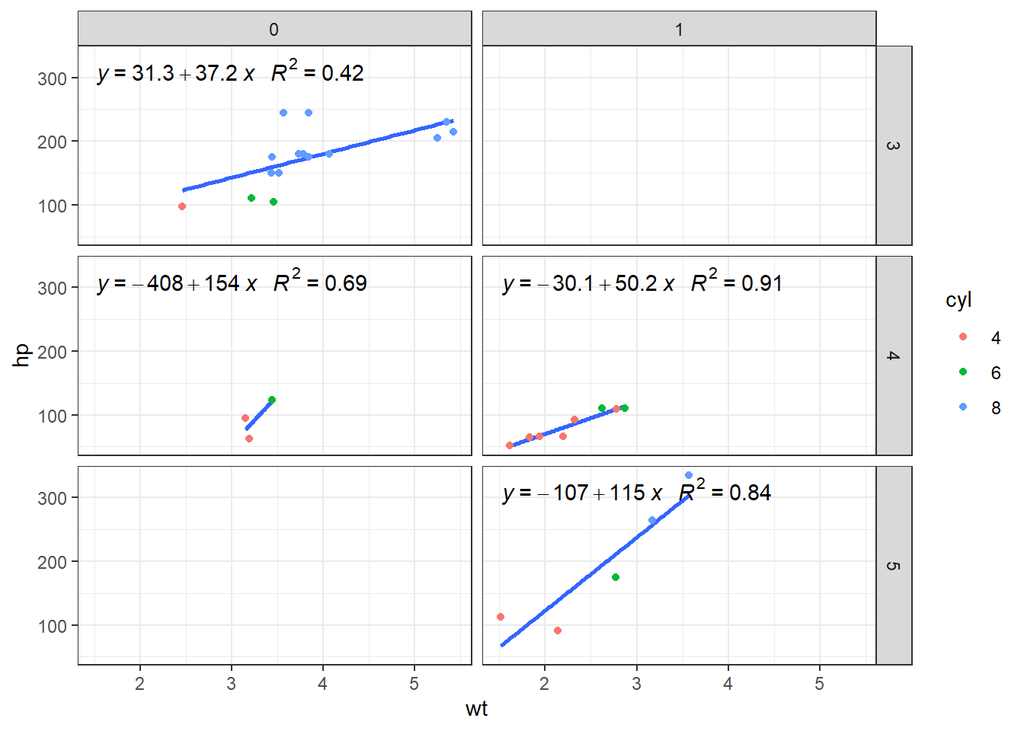

```r
g + facet_grid(gear ~ am)
```

#### Gráfico de dispersão com 1 grupo - Adicionar TÍTULO

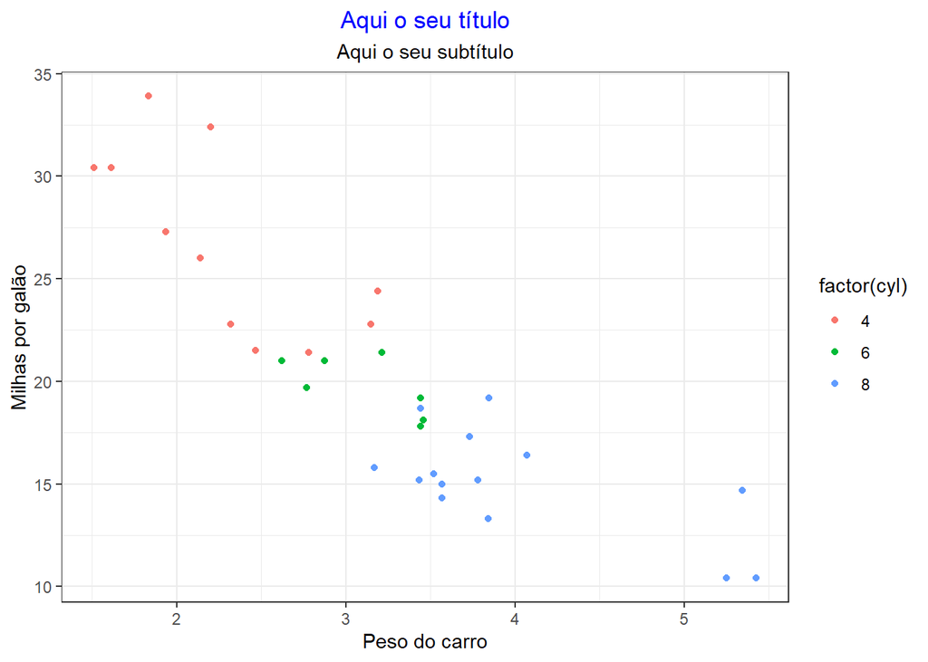

```r
ggplot(mtcars, aes(wt, mpg, colour = factor(cyl))) +
  geom_point() +
  #Adicionar título e subtítulo
  labs(title = "Aqui o seu título", subtitle = "Aqui o seu subtítulo")+
  #título do eixo x
  xlab(label = "Peso do carro") +
  #título do eixo y
  ylab(label = "Milhas por galão") +
  #centralizando o título
  theme(plot.title = element_text(hjust = 0.5)) +
  #centralizando o subtítulo
  theme(plot.subtitle = element_text(hjust = 0.5))+
  #mudando a cor do título
  theme(plot.title = element_text(color = "blue"))
```

#### Opções de customização do texto

```r
?element_text
```

#### PIRAMIDE ETÁRIA

Carregar os dados da pirâmide etária

```r
source("dados.R")
kable(head(data))
```

| Age | Gender | Population | PopPerc | signal |
| --- | --- | --- | --- | --- |
| 0-4 | M | 7454197 | 3.53 | 1 |
| 0-4 | F | 7117753 | -3.37 | -1 |
| 5-9 | M | 7469798 | 3.54 | 1 |
| 5-9 | F | 7146432 | -3.39 | -1 |
| 10-14 | M | 7727130 | 3.66 | 1 |
| 10-14 | F | 7424459 | -3.52 | -1 |

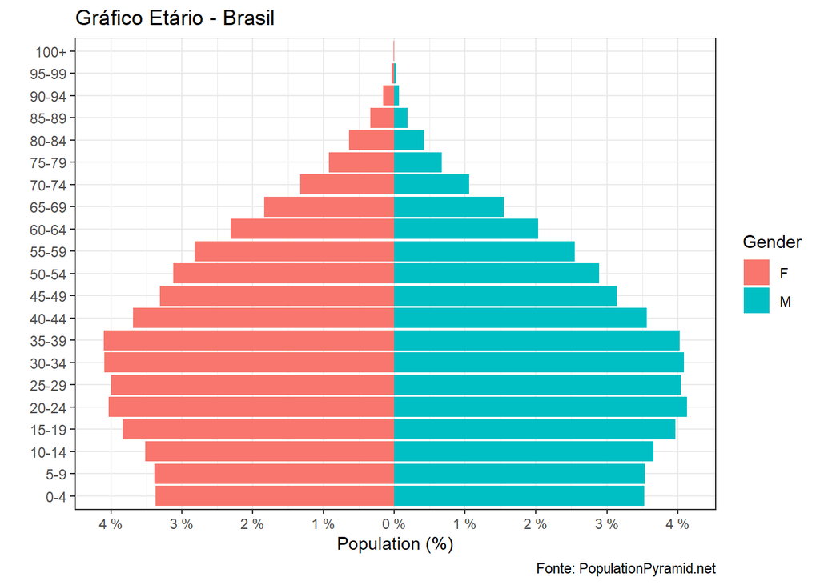

```r
ggplot(data)+
  # Gerar a estrutura do gráfico e colorir por sexo
  geom_bar(aes(x=Age,y=PopPerc,fill=Gender),stat='identity')+
  # Girar o gráfico
  coord_flip()+
  # arrumar valores do eixo x
  scale_y_continuous(breaks=seq(-10,10,1),
                     labels=function(x){paste(abs(x),'%')})+
  # títulos
  labs(x='',y='Population (%)',
       title='Gráfico Etário - Brasil',
       caption='Fonte: PopulationPyramid.net')
```

#### Como criar Boxplots

##### definir tema clássico

```r
theme_set(theme_classic())
```

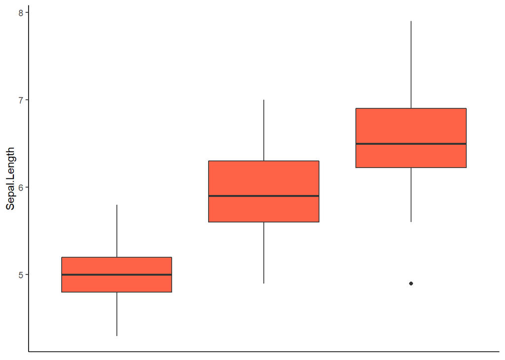

```r
g <- ggplot(iris, aes(x = Species, y = Sepal.Length))
g + geom_boxplot(varwidth=T, fill="tomato") +
  ### girar os valores do eixo x
  theme(axis.text.x = element_text(angle=60))+
  # ajustar os valores verticalmente
  theme(axis.text.x = element_text(vjust=0.6,angle=60))+
  ## remover título, valores e tracinho do eixo x
  theme(axis.title.x=element_blank(), #remove o titulo
        axis.text.x=element_blank(), #remove o texto do valor
        axis.ticks.x=element_blank()) #remove o tracinho
```

#### BÔNUS 1

```r
# install.packages("ggthemes")
library(ggthemes)
```

Nossos dados:

```r
kable(head(ToothGrowth))
```

| len | supp | dose |
| --- | --- | --- |
| 4.2 | VC | 0.5 |
| 11.5 | VC | 0.5 |
| 7.3 | VC | 0.5 |
| 5.8 | VC | 0.5 |
| 6.4 | VC | 0.5 |
| 10.0 | VC | 0.5 |

Construindo boxplots para os grupos de *dose* pela variável *len*

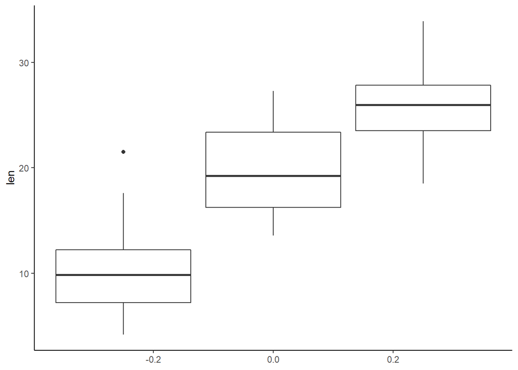

```r
ggplot(ToothGrowth, aes(y = len,group=dose)) +
  geom_boxplot()
```

#### Transformar a variável *dose* de numérica para categórica

```r
ToothGrowth$dose <- as.factor(ToothGrowth$dose)
```

#### usando o tema da biblioteca ggthemes

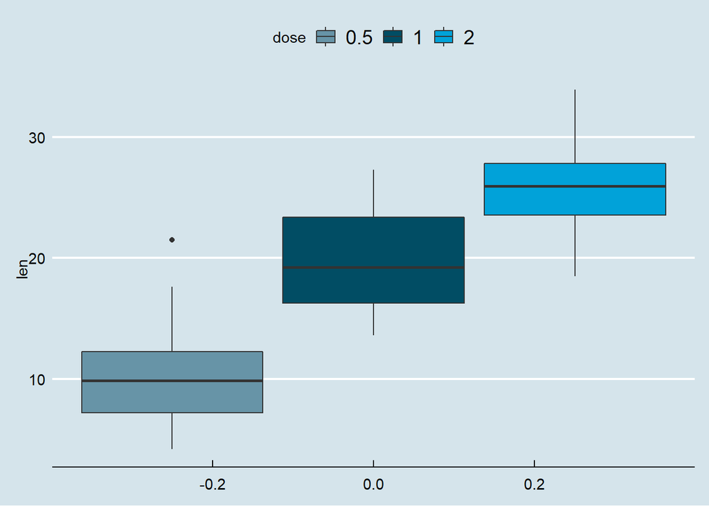

```r
ggplot(ToothGrowth, aes(y = len, group=dose)) +
  geom_boxplot(aes(fill = dose)) +
  theme_economist() + scale_fill_economist()
```

#### BÔNUS 2

Como circular um mapa e marcar os pontos que você deseja

```r
devtools::install_github("dkahle/ggmap")
devtools::install_github("hrbrmstr/ggalt")
```

```r
library(ggmap)
library(ggalt)
```

Você precisa entrar no site do google, fazer o seu cadastro e copiar o seu token:

[**https://cloud.google.com/maps-platform/**](https://cloud.google.com/maps-platform/)

Link da biblioteca:

[**https://github.com/dkahle/ggmap**](https://github.com/dkahle/ggmap)

#### Fazer autenticação

```r
register_google(key = "[your key]", write = TRUE)
```

#### Coordenadas de Belo Horizonte

```r
bh <-  geocode("Belo Horizonte")  # longitude e latitude
```

#### Buscar os mapas

##### Google Satellite Map

```r
bh_sat_map <- qmap("Belo Horizonte", zoom=12, source = "google", maptype="satellite")
```

##### Google Road Map

```r
bh_road_map <- qmap("Belo Horizonte", zoom=12, source = "google", maptype="roadmap")
```

##### Google Hybrid Map

```r
bh_hybrid_map <- qmap("Belo Horizonte", zoom=12, source = "google", maptype="hybrid")
```

##### Pegar coordenadas de alguns lugares da cidade

```r
lugares_bh <- c("Padre Eustáquio",
                "Savassi",
                "Estádio Mineirão")
```

```r
lugares_bh_loc <- geocode(lugares_bh)  # long e lat
lugares_bh_loc
```

```
## # A tibble: 3 x 2
##     lon   lat
##   <dbl> <dbl>
## 1 -44.0 -19.9
## 2 -43.9 -19.9
## 3 -44.0 -19.9
```

##### MAPA COM AS MARCAÇÕES

[figure not shown]

```r
# escolha um dos três abaixo: bh_hybrid_map ou bh_sat_map ou bh_road_map

# bh_hybrid_map+
# bh_sat_map+
bh_road_map +

### marcar os pontos escolhidos
geom_point(aes(x=lon, y=lat),
data = lugares_bh_loc,
alpha = 0.7,
size = 7,
color = "tomato") +
## Criar o círculo
geom_encircle(aes(x=lon, y=lat),
data = lugares_bh_loc,
size = 2, color = "blue")
```

#### LIVRO DO GGPLOT -> [**https://ggplot2-book.org/**](https://ggplot2-book.org/)

Espero que tenha gostado do material complementar!

Continue acompanhando o meu trabalho e me ajude a divulgar para mais pessoas! :)

Blog: [**luisotavio.pro**](https://www.luisotavio.pro)

Instagram: [**instagram.com/luisotavio.pro**](https://instagram.com/luisotavio.pro)

Youtube: [**youtube.com/c/luisotaviopro**](https://youtube.com/c/luisotaviopro)